# Fig1

## DESEQ

```r
mergedcoldata <- data.frame(condition = ifelse(str_detect(colnames(mergeddf)[2:33], pattern = "NT|WT"), "WT",
                                               ifelse(str_detect(colnames(mergeddf)[2:33], pattern = "HIF1a"), "HIF1a",
                                                      ifelse(str_detect(colnames(mergeddf)[2:33], pattern = "HIF2a"), "HIF2a",
                                                             ifelse(str_detect(colnames(mergeddf)[2:33], pattern = "Belz"), "Bel","NC")
                                                      )
                                               )
),
id = str_split(colnames(mergeddf)[2:33], pattern = "_|-", simplify = T)[,2],
batch = c(rep("new",16),rep("old",16))
)

mergedcoldata$sample <- colnames(mergeddf)[2:33]
mergedcoldata$condition <- factor(mergedcoldata$condition, levels = c("WT", "NC","Bel", "HIF1a", "HIF2a"))
rownames(mergedcoldata) <- mergedcoldata$sample




######## deseq

deseq.custom <- function(dfset, coldata, cond, paired = F, batch = F){
  if(length(cond) != 1 ){
    message("2 group should be provided with |")
    message("For example, A|B")
    exit
  }
  coldata.comparison <- coldata %>% filter(str_detect(condition, pattern = cond))
  dfset.comparison <- dfset %>% dplyr::select(coldata.comparison$sample)
  rownames(dfset.comparison) <- dfset$gene_id
  print(colnames(dfset.comparison))
  if(paired){
    if(batch){
      dds <- DESeqDataSetFromMatrix(round(dfset.comparison), colData = coldata.comparison, design = ~id + batch + condition)
    }else{
      dds <- DESeqDataSetFromMatrix(round(dfset.comparison), colData = coldata.comparison, design = ~id + condition)
    }
  }else{
    dds <- DESeqDataSetFromMatrix(round(dfset.comparison), colData = coldata.comparison, design = ~ condition)
  }
  dds <- DESeq(dds)
  res <- results(dds)
  res.dfset <- data.frame(res)
  res.dfset$gene <- rownames(res.dfset)

  res.dfset$genename <- dfset$genename

  return(res.dfset)
}


WTvsHIF1apairedfinal <- deseq.custom(mergeddf,coldata = mergedcoldata, cond = "HIF1a|WT", paired = T, batch = F)
```

```
##  [1] "Sample_46-HIF1alpha_278_299" "Sample_46-WT_207_370"
##  [3] "Sample_55-HIF1alpha_230_347" "Sample_55-WT_254_323"
##  [5] "Sample_59-HIF1alpha_277_300" "Sample_59-WT_206_371"
##  [7] "Sample_60-HIF1alpha_229_348" "Sample_60-WT_253_324"
##  [9] "LRS_36_HIF1a_KO_327_250"     "LRS_36_NT_339_238"
## [11] "LRS_38_HIF1a_KO_374_203"     "LRS_38_NT_291_286"
## [13] "LRS_42_HIF1a_KO_326_251"     "LRS_42_NT_338_239"
## [15] "LRS_43_HIF1a_KO_373_204"     "LRS_43_NT_290_287"
```

```
## factor levels were dropped which had no samples
```

```r
WTvsHIF1apairedfinal <- WTvsHIF1apairedfinal %>%
  mutate(color = case_when(padj < 0.05 & log2FoldChange > 1 ~ "red",
                           padj < 0.05 & log2FoldChange < -1 ~ "blue",
                           TRUE ~ "grey"),
         label = if_else(genename %in% c("VEGFA","PGK1","CXCR5","CXCR6"), genename,""))


### remove 38 and 42 according to KO data, see text
WTvsHIF2apairedfinal <- deseq.custom(mergeddf %>% select(-starts_with("LRS_42"), -starts_with("LRS_38")),coldata = mergedcoldata %>% dplyr::filter(id != 42 & id !=38), cond = "HIF2a|WT", paired = T, batch = F)
```

[output not shown]

```
##  [1] "Sample_46-HIF2alpha_266_311" "Sample_46-WT_207_370"
##  [3] "Sample_55-HIF2alpha_218_359" "Sample_55-WT_254_323"
##  [5] "Sample_59-HIF2alpha_265_312" "Sample_59-WT_206_371"
##  [7] "Sample_60-HIF2alpha_217_360" "Sample_60-WT_253_324"
##  [9] "LRS_36_HIF2a_KO_315_262"     "LRS_36_NT_339_238"
## [11] "LRS_43_HIF2a_KO_361_216"     "LRS_43_NT_290_287"
```

```
## factor levels were dropped which had no samples
```

```r
WTvsHIF2apairedfinal <- WTvsHIF2apairedfinal %>%
  mutate(color = case_when(padj < 0.05 & log2FoldChange > 1 ~ "red",
                           padj < 0.05 & log2FoldChange < -1 ~ "blue",
                           TRUE ~ "grey"),
         label = if_else(genename %in% c("IFNG","IL2","TNF", "EPAS1"), genename,""))
```

### Figure 1

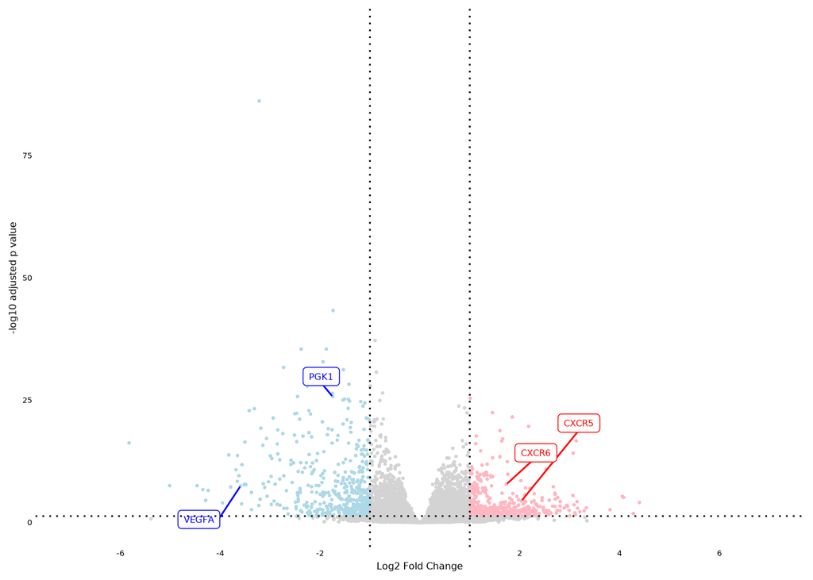

```r
ggplot(WTvsHIF1apairedfinal, aes(x = log2FoldChange, y = -log10(padj))) +
  rasterise(geom_point(aes(color = color),size = 0.2), dpi = 600) +
  scale_color_manual(values = c("lightblue","lightgrey","lightpink")) +
  new_scale_color() +
  geom_label_repel(aes(label = label, color = color),size = 2, max.overlaps = 10000000) +
  scale_color_manual(values = c("blue","grey","red")) +
  geom_vline(xintercept = 1, linetype = 3) +
  geom_vline(xintercept = -1, linetype = 3) +
  geom_hline(yintercept = -log10(0.05), linetype = 3) +
  scale_x_continuous(breaks = c(-6,-4,-2,2,4,6), limits = c(-7,7)) +
  scale_y_continuous(breaks = c(0,25,50,75), limits = c(0,100)) +
  labs(x = "Log2 Fold Change", y = "-log10 adjusted p value") +
  theme_classic() +
  theme(axis.line = element_blank(),
        axis.ticks = element_blank(),
        legend.position = "none",
        text = element_text(size = 6))
```

```r
ggsave("WTvsHIF1aKO.png", width = 3, height = 2, units = "in")
ggsave("WTvsHIF1aKO.svg", width = 3, height = 2, units = "in")
```

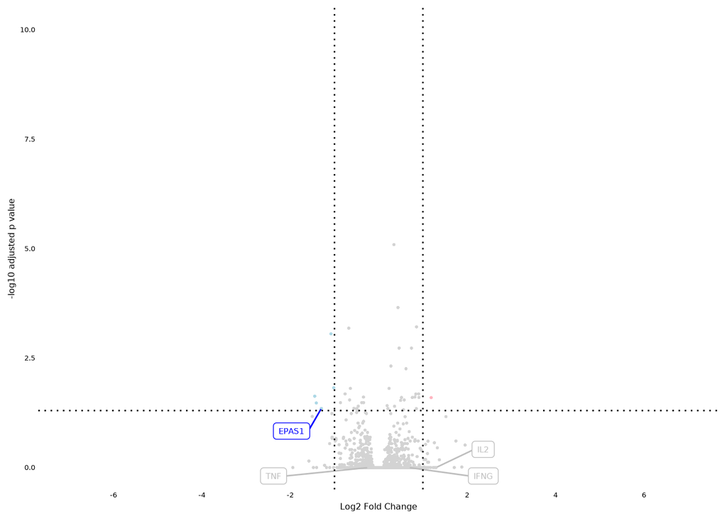

```r
ggplot(WTvsHIF2apairedfinal, aes(x = log2FoldChange, y = -log10(padj))) +
  rasterise(geom_point(aes(color = color),size = 0.2), dpi = 600) +
  scale_color_manual(values = c("lightblue","lightgrey","lightpink")) +
  new_scale_color() +
  geom_label_repel(aes(label = label, color = color),size = 2, max.overlaps = 10000000) +
  scale_color_manual(values = c("blue","grey","red")) +
  geom_vline(xintercept = 1, linetype = 3) +
  geom_vline(xintercept = -1, linetype = 3) +
  geom_hline(yintercept = -log10(0.05), linetype = 3) +
  scale_x_continuous(breaks = c(-6,-4,-2,2,4,6), limits = c(-7,7)) +
  scale_y_continuous(breaks = c(0,2.5,5,7.5,10), limits = c(0,10)) +
  labs(x = "Log2 Fold Change", y = "-log10 adjusted p value") +
  theme_classic() +
  theme(axis.line = element_blank(),
        axis.ticks = element_blank(),
        legend.position = "none",
        text = element_text(size = 6))
```

```r
ggsave("WTvsHIF2aKO.png", width = 3, height = 2, units = "in")
ggsave("WTvsHIF2aKO.svg", width = 3, height = 2, units = "in")
```

### Supplementary Figure 1

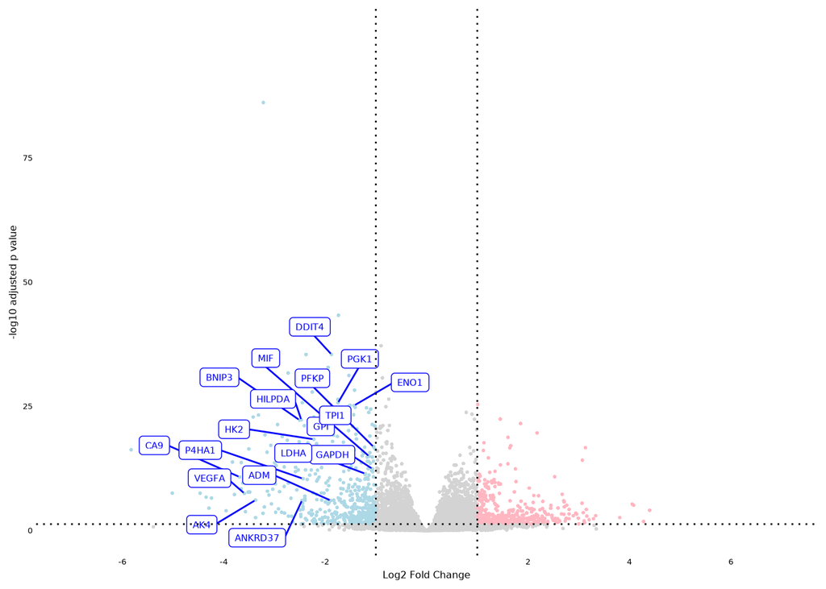

```r
############ gene list ########
hif <- read.table("./20260805hypoxiagenelist.txt")

WTvsHIF1apairedfinal <- WTvsHIF1apairedfinal %>%
  mutate(color = case_when(padj < 0.05 & log2FoldChange > 1 ~ "red",
                           padj < 0.05 & log2FoldChange < -1 ~ "blue",
                           TRUE ~ "grey"),
         label = if_else(genename %in% hif$V1 & abs(padj) < 0.05 & abs(log2FoldChange) > 1, genename,""))


ggplot(WTvsHIF1apairedfinal, aes(x = log2FoldChange, y = -log10(padj))) +
  rasterise(geom_point(aes(color = color),size = 0.2), dpi = 600) +
  scale_color_manual(values = c("lightblue","lightgrey","lightpink")) +
  new_scale_color() +
  geom_label_repel(aes(label = label, color = color),size = 2, max.overlaps = 10000000) +
  scale_color_manual(values = c("blue","grey","red")) +
  geom_vline(xintercept = 1, linetype = 3) +
  geom_vline(xintercept = -1, linetype = 3) +
  geom_hline(yintercept = -log10(0.05), linetype = 3) +
  scale_x_continuous(breaks = c(-6,-4,-2,2,4,6), limits = c(-7,7)) +
  scale_y_continuous(breaks = c(0,25,50,75), limits = c(0,100)) +
  labs(x = "Log2 Fold Change", y = "-log10 adjusted p value") +
  theme_classic() +
  theme(axis.line = element_blank(),
        axis.ticks = element_blank(),
        legend.position = "none",
        text = element_text(size = 6))
```

```r
ggsave("WTvsHIF1aKO_Hypoxiagenes.png", width = 3, height = 2, units = "in")
ggsave("WTvsHIF1aKO_Hypoxiagenes.svg", width = 3, height = 2, units = "in")
ggsave("WTvsHIF1aKO_Hypoxiagenes_large.png", width = 6, height = 4, units = "in")
ggsave("WTvsHIF1aKO_Hypoxiagenes_large.svg", width = 6, height = 4, units = "in")
```

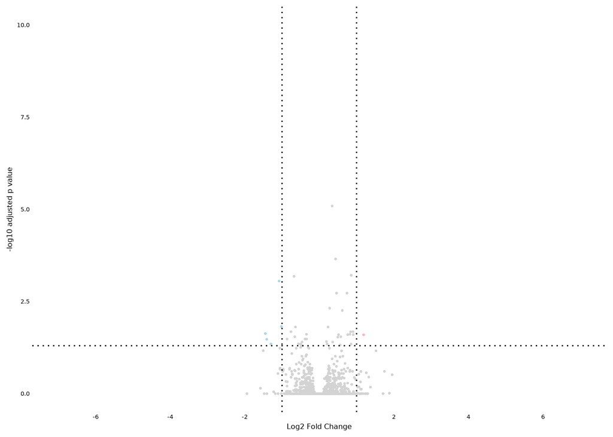

```r
WTvsHIF2apairedfinal <- WTvsHIF2apairedfinal %>%
  mutate(color = case_when(padj < 0.05 & log2FoldChange > 1 ~ "red",
                           padj < 0.05 & log2FoldChange < -1 ~ "blue",
                           TRUE ~ "grey"),
         label = if_else(genename %in% hif$V1 & abs(padj) < 0.05, genename,""))


ggplot(WTvsHIF2apairedfinal, aes(x = log2FoldChange, y = -log10(padj))) +
  rasterise(geom_point(aes(color = color),size = 0.2), dpi = 600) +
  scale_color_manual(values = c("lightblue","lightgrey","lightpink")) +
  new_scale_color() +
  geom_label_repel(aes(label = label, color = color),size = 2, max.overlaps = 10000000) +
  scale_color_manual(values = c("blue","grey","red")) +
  geom_vline(xintercept = 1, linetype = 3) +
  geom_vline(xintercept = -1, linetype = 3) +
  geom_hline(yintercept = -log10(0.05), linetype = 3) +
  scale_x_continuous(breaks = c(-6,-4,-2,2,4,6), limits = c(-7,7)) +
  scale_y_continuous(breaks = c(0,2.5,5,7.5,10), limits = c(0,10)) +
  labs(x = "Log2 Fold Change", y = "-log10 adjusted p value") +
  theme_classic() +
  theme(axis.line = element_blank(),
        axis.ticks = element_blank(),
        legend.position = "none",
        text = element_text(size = 6))
```

```r
ggsave("WTvsHIF2aKO_hypoxia.png", width = 3, height = 2, units = "in")
ggsave("WTvsHIF2aKO_hypoxia.svg", width = 3, height = 2, units = "in")
```

### save files

```r
write.csv(WTvsHIF1apairedfinal, file = "results/WTvsHIF1afinal.csv", quote = F,row.names = T,
          col.names = F)
write.csv(WTvsHIF2apairedfinal, file = "results/WTvsHIF2afinal.csv", quote = F,row.names = T,
          col.names = F)
write.csv(mergeddf, file = "results/finaldf.csv", quote = F,row.names = T,
          col.names = F)
```

### Enrichment analysis

```r
res_hif1a_df <- read_csv("results/WTvsHIF1afinal.csv" )
res_hif2a_df <- read_csv("results/WTvsHIF2afinal.csv" )
```

```
## ──────────────────────────────────────────────────────── Delimiter: "," chr
## (2): genename, color dbl (8): ...1, baseMean, log2FoldChange, lfcSE, stat,
## pvalue, padj, gene lgl (1): label
```

```r
# Add ENTREZID mapping to both dataframes
res_hif1a_df$ENTREZID <- mapIds(org.Hs.eg.db,
                                keys = res_hif1a_df$genename,
                                column = "ENTREZID",
                                keytype = "SYMBOL",
                                multiVals = "first")
res_hif2a_df$ENTREZID <- mapIds(org.Hs.eg.db,
                                keys = res_hif2a_df$genename,
                                column = "ENTREZID",
                                keytype = "SYMBOL",
                                multiVals = "first")
# Define thresholds
padj_threshold <- 0.05
#lfc_threshold <- 0
lfc_threshold <- 1

# HIF1a gene lists
hif1a_up_genes <- res_hif1a_df %>%
  dplyr::filter(padj < padj_threshold & log2FoldChange > lfc_threshold) %>%
  dplyr::pull(ENTREZID) %>%
  na.omit() %>%
  as.character()

hif1a_down_genes <-  res_hif1a_df %>%
  dplyr::filter(padj < padj_threshold & log2FoldChange < -lfc_threshold) %>%
  dplyr::pull(ENTREZID) %>%
  na.omit() %>%
  as.character()

# HIF2a gene lists
hif2a_up_genes <-  res_hif2a_df %>%
  dplyr::filter(padj < padj_threshold & log2FoldChange > lfc_threshold) %>%
  dplyr::pull(ENTREZID) %>%
  na.omit() %>%
  as.character()

hif2a_down_genes <-  res_hif2a_df %>%
  dplyr::filter(padj < padj_threshold & log2FoldChange < -lfc_threshold) %>%
  dplyr::pull(ENTREZID) %>%
  na.omit() %>%
  as.character()

# Universe
universe <-  res_hif1a_df %>%
  dplyr::pull(ENTREZID) %>%
  na.omit() %>%
  as.character()

message("Gene counts for enrichment:")
```

```
## Gene counts for enrichment:
```

```r
message(paste("HIF1a Up:", length(hif1a_up_genes)))
```

```
## HIF1a Up: 374
```

```r
message(paste("HIF1a Down:", length(hif1a_down_genes)))
```

```
## HIF1a Down: 360
```

```r
message(paste("HIF2a Up:", length(hif2a_up_genes)))
```

```
## HIF2a Up: 1
```

```r
message(paste("HIF2a Down:", length(hif2a_down_genes)))
```

```
## HIF2a Down: 5
```

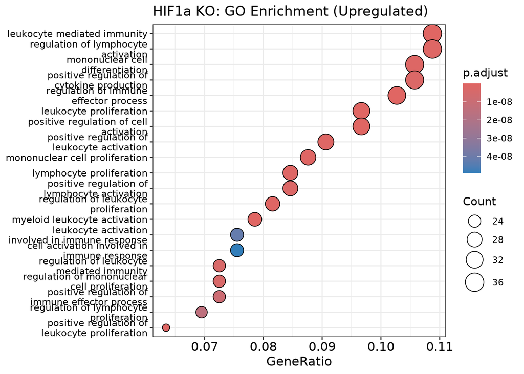

```r
## HIF1a Pathway Analysis
# GO enrichment for HIF1a upregulated genes
hif1a_go_up <- NULL
if(length(hif1a_up_genes) > 5) {
  hif1a_go_up <- enrichGO(
    gene = hif1a_up_genes,
    universe = universe,
    keyType = "ENTREZID",
    OrgDb = org.Hs.eg.db,
    ont = "ALL",
    pAdjustMethod = "BH",
    pvalueCutoff = 0.05,
    qvalueCutoff = 0.2,
    readable = TRUE
  )

  if(nrow(as.data.frame(hif1a_go_up)) > 0) {
    p <- dotplot(hif1a_go_up, showCategory = 20) +
      ggtitle("HIF1a KO: GO Enrichment (Upregulated)") +
      theme(axis.text.y = element_text(size = 9))
    print(p)
  } else {
    message("No significant GO terms for HIF1a upregulated genes")
  }
}
```

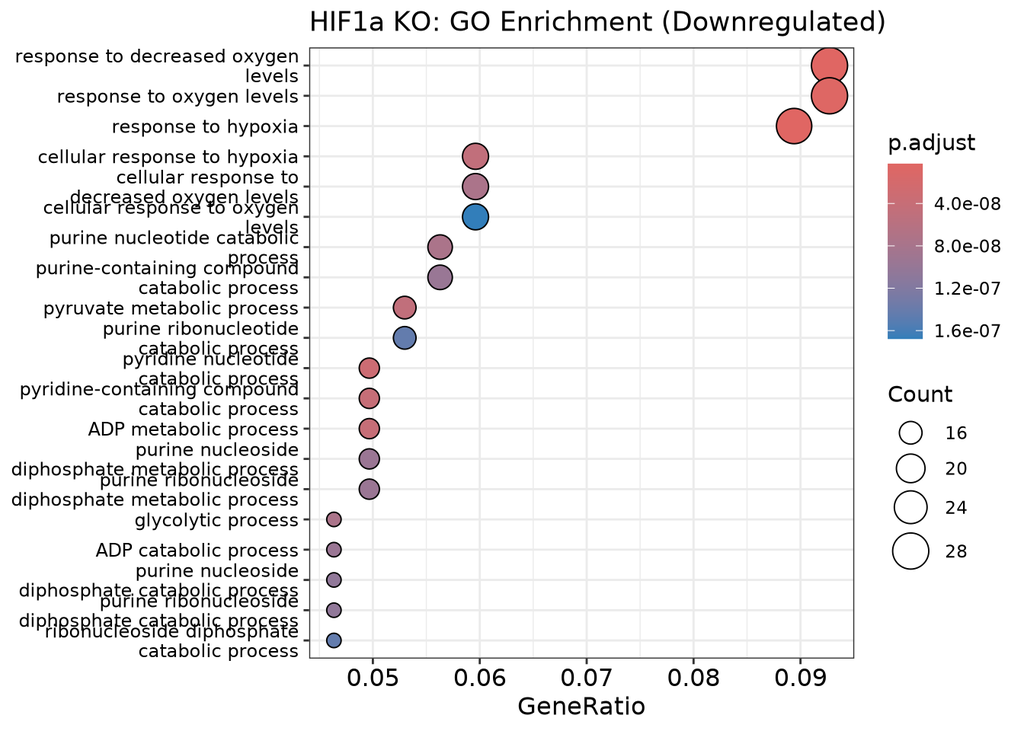

```r
# GO enrichment for HIF1a downregulated genes
hif1a_go_down <- NULL
if(length(hif1a_down_genes) > 5) {
  hif1a_go_down <- enrichGO(
    gene = hif1a_down_genes,
    universe = universe,
    keyType = "ENTREZID",
    OrgDb = org.Hs.eg.db,
    ont = "ALL",
    pAdjustMethod = "BH",
    pvalueCutoff = 0.05,
    qvalueCutoff = 0.2,
    readable = TRUE
  )

  if(nrow(as.data.frame(hif1a_go_down)) > 0) {
    p <- dotplot(hif1a_go_down, showCategory = 20) +
      ggtitle("HIF1a KO: GO Enrichment (Downregulated)") +
      theme(axis.text.y = element_text(size = 9))
    print(p)
  } else {
    message("No significant GO terms for HIF1a downregulated genes")
  }
}
```

```
## Reading KEGG annotation online: "https://rest.kegg.jp/link/hsa/pathway"...
## Reading KEGG annotation online: "https://rest.kegg.jp/list/pathway/hsa"...
```

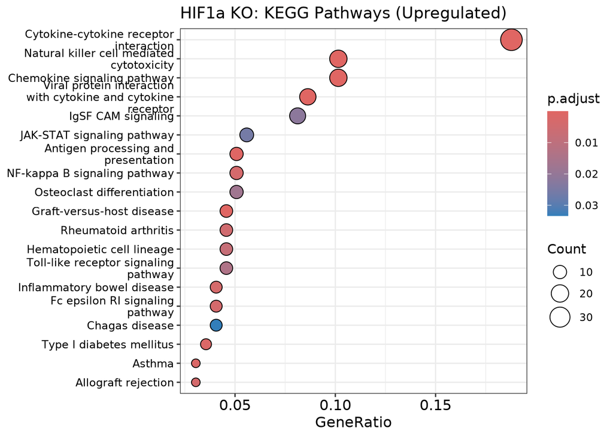

```r
# KEGG enrichment for HIF1a
hif1a_kegg_up <- NULL
if(length(hif1a_up_genes) > 5) {
  hif1a_kegg_up <- enrichKEGG(
    gene = hif1a_up_genes,
    universe = universe,
    organism = "hsa",
    pvalueCutoff = 0.05,
    qvalueCutoff = 0.2
  )

  if(nrow(as.data.frame(hif1a_kegg_up)) > 0) {
    hif1a_kegg_up <- setReadable(hif1a_kegg_up, OrgDb = org.Hs.eg.db, keyType = "ENTREZID")
    p <- dotplot(hif1a_kegg_up, showCategory = 20) +
      ggtitle("HIF1a KO: KEGG Pathways (Upregulated)") +
      theme(axis.text.y = element_text(size = 9))
    print(p)
  } else {
    message("No significant KEGG pathways for HIF1a upregulated genes")
  }
}
```

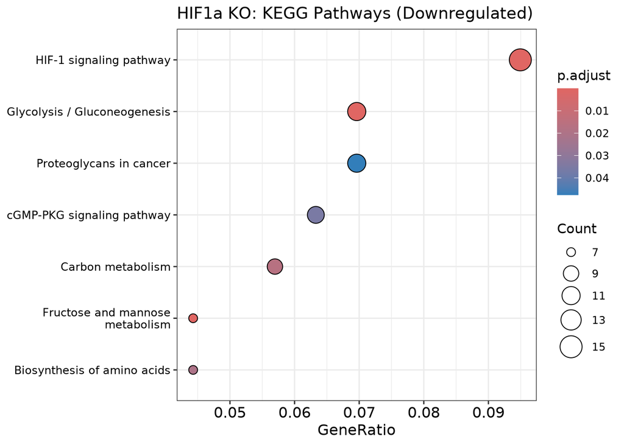

```r
hif1a_kegg_down <- NULL
if(length(hif1a_down_genes) > 5) {
  hif1a_kegg_down <- enrichKEGG(
    gene = hif1a_down_genes,
    universe = universe,
    organism = "hsa",
    pvalueCutoff = 0.05,
    qvalueCutoff = 0.2
  )

  if(nrow(as.data.frame(hif1a_kegg_down)) > 0) {
    hif1a_kegg_down <- setReadable(hif1a_kegg_down, OrgDb = org.Hs.eg.db, keyType = "ENTREZID")
    p <- dotplot(hif1a_kegg_down, showCategory = 20) +
      ggtitle("HIF1a KO: KEGG Pathways (Downregulated)") +
      theme(axis.text.y = element_text(size = 9))
    print(p)
  } else {
    message("No significant KEGG pathways for HIF1a downregulated genes")
  }
}
```

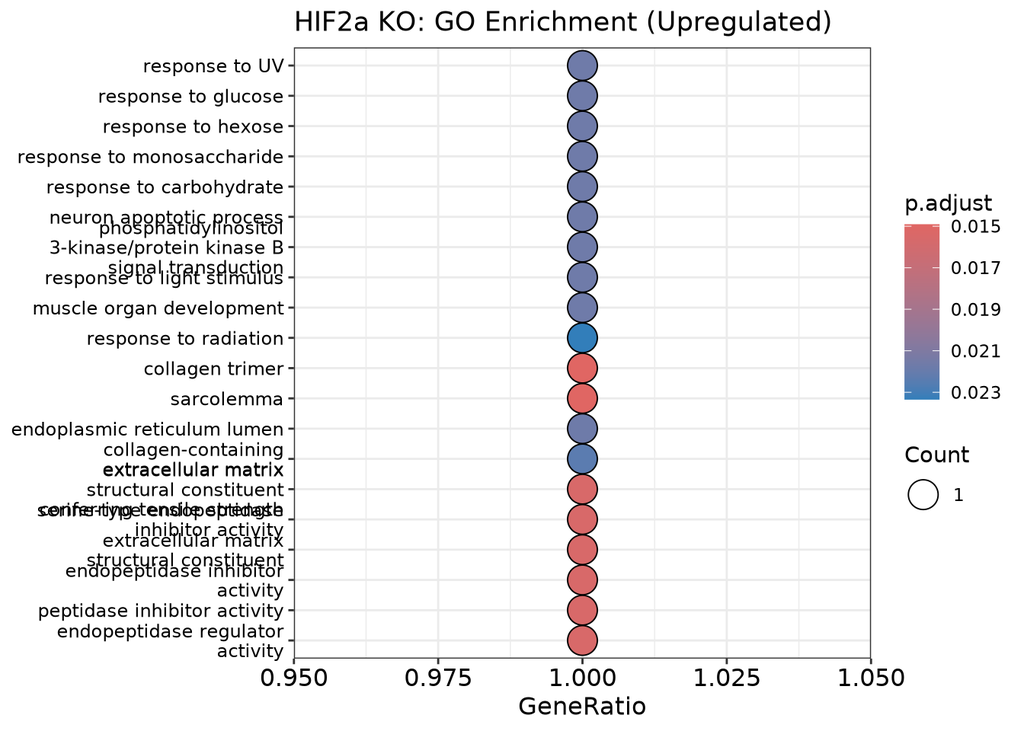

```r
## HIF2a Pathway Analysis

# GO enrichment for HIF2a upregulated genes
hif2a_go_up <- NULL
if(length(hif2a_up_genes) > 0) {
  hif2a_go_up <- enrichGO(
    gene = hif2a_up_genes,
    universe = universe,
    keyType = "ENTREZID",
    OrgDb = org.Hs.eg.db,
    ont = "ALL",
    pAdjustMethod = "BH",
    pvalueCutoff = 0.05,
    qvalueCutoff = 0.2,
    readable = TRUE
  )

  if(nrow(as.data.frame(hif2a_go_up)) > 0) {
    p <- dotplot(hif2a_go_up, showCategory = 20) +
      ggtitle("HIF2a KO: GO Enrichment (Upregulated)") +
      theme(axis.text.y = element_text(size = 9))
    print(p)
  } else {
    message("No significant GO terms for HIF2a upregulated genes")
  }
}
```

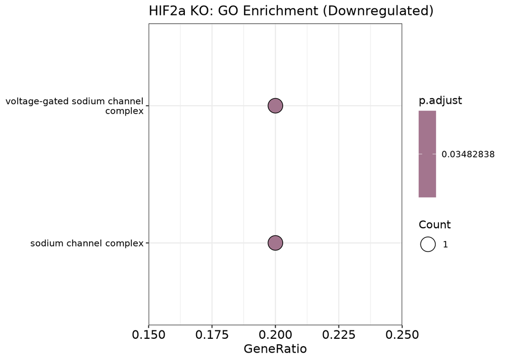

```r
# GO enrichment for HIF2a downregulated genes
hif2a_go_down <- NULL
if(length(hif2a_down_genes) > 0) {
  hif2a_go_down <- enrichGO(
    gene = hif2a_down_genes,
    universe = universe,
    keyType = "ENTREZID",
    OrgDb = org.Hs.eg.db,
    ont = "ALL",
    pAdjustMethod = "BH",
    pvalueCutoff = 0.05,
    qvalueCutoff = 0.2,
    readable = TRUE
  )

  if(nrow(as.data.frame(hif2a_go_down)) > 0) {
    p <- dotplot(hif2a_go_down, showCategory = 20) +
      ggtitle("HIF2a KO: GO Enrichment (Downregulated)") +
      theme(axis.text.y = element_text(size = 9))
    print(p)
  } else {
    message("No significant GO terms for HIF2a downregulated genes")
  }
}
```

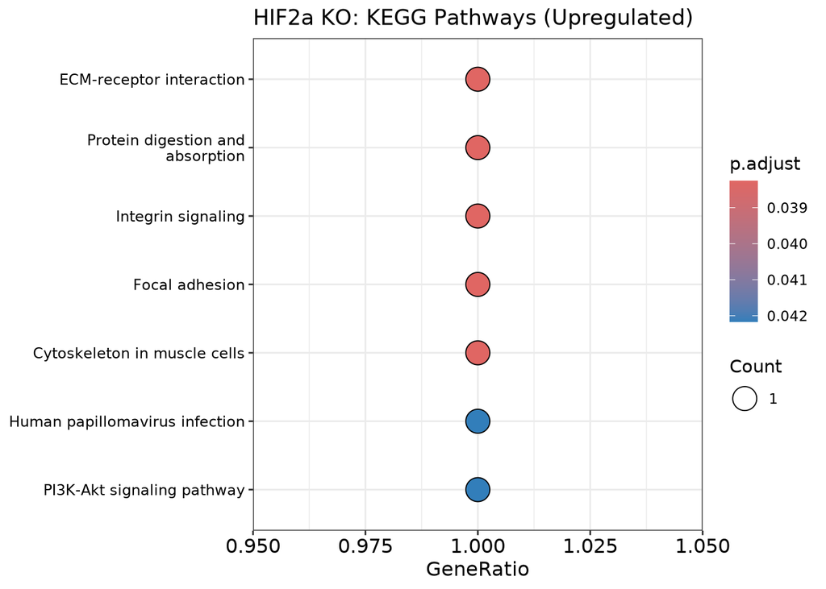

```r
# KEGG enrichment for HIF2a
hif2a_kegg_up <- NULL
if(length(hif2a_up_genes) > 0) {
  hif2a_kegg_up <- enrichKEGG(
    gene = hif2a_up_genes,
    universe = universe,
    organism = "hsa",
    pvalueCutoff = 0.05,
    qvalueCutoff = 0.2
  )

  if(nrow(as.data.frame(hif2a_kegg_up)) > 0) {
    hif2a_kegg_up <- setReadable(hif2a_kegg_up, OrgDb = org.Hs.eg.db, keyType = "ENTREZID")
    p <- dotplot(hif2a_kegg_up, showCategory = 20) +
      ggtitle("HIF2a KO: KEGG Pathways (Upregulated)") +
      theme(axis.text.y = element_text(size = 9))
    print(p)
  } else {
    message("No significant KEGG pathways for HIF2a upregulated genes")
  }
}
```

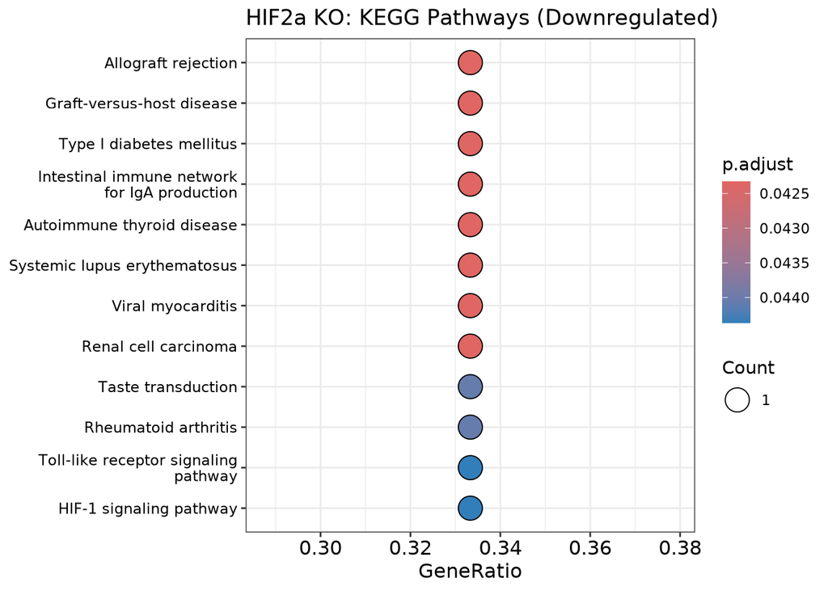

```r
hif2a_kegg_down <- NULL
if(length(hif2a_down_genes) > 0) {
  hif2a_kegg_down <- enrichKEGG(
    gene = hif2a_down_genes,
    universe = universe,
    organism = "hsa",
    pvalueCutoff = 0.05,
    qvalueCutoff = 0.2
  )

  if(nrow(as.data.frame(hif2a_kegg_down)) > 0) {
    hif2a_kegg_down <- setReadable(hif2a_kegg_down, OrgDb = org.Hs.eg.db, keyType = "ENTREZID")
    p <- dotplot(hif2a_kegg_down, showCategory = 20) +
      ggtitle("HIF2a KO: KEGG Pathways (Downregulated)") +
      theme(axis.text.y = element_text(size = 9))
    print(p)
  } else {
    message("No significant KEGG pathways for HIF2a downregulated genes")
  }
}
```

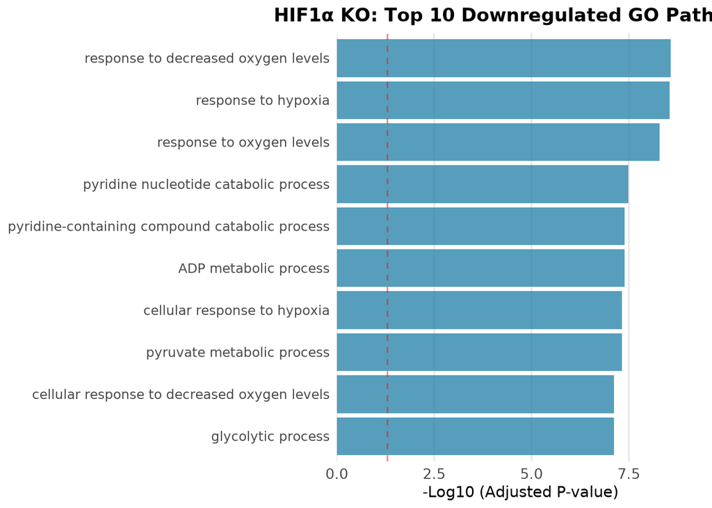

```r
###save
write.csv(as.data.frame(hif1a_go_up), file = "results/hif1agoup.csv", quote = F)
write.csv(as.data.frame(hif1a_go_down), file = "results/hif1agodown.csv", quote = F)
write.csv(as.data.frame(hif2a_go_up), file = "results/hif2agoup.csv", quote = F)
write.csv(as.data.frame(hif2a_go_down), file = "results/hif2agodown.csv", quote = F)


write.csv(as.data.frame(hif1a_kegg_up), file = "results/hif1akeggup.csv", quote = F)
write.csv(as.data.frame(hif1a_kegg_down), file = "results/hif1akeggdown.csv", quote = F)
write.csv(as.data.frame(hif2a_kegg_up), file = "results/hif2akeggup.csv", quote = F)
write.csv(as.data.frame(hif2a_kegg_down), file = "results/hif2akeggdown.csv", quote = F)


# Function to create pathway bar plot
create_pathway_barplot <- function(data, title, n_pathways = 10, bar_color = "#2E86AB") {

  # tryCatch
  df <- tryCatch({
    data
  }, error = function(e) {
    return(NULL)
  })

  if (!length(df) > 0) {
    message("No enrichment data")
    return(NULL)
  }

  # Select top pathways and prepare data
  plot_data <- data %>%
    arrange(p.adjust) %>%
    slice_head(n = n_pathways) %>%
    mutate(
      neglog10_padj = -log10(p.adjust),
      # Wrap long descriptions for better display
      Description = str_wrap(Description, width = 50),
      # Order by significance for plotting
      Description = factor(Description, levels = rev(Description))
    )

  # Create bar plot
  p <- ggplot(plot_data, aes(x = neglog10_padj, y = Description)) +
    geom_bar(stat = "identity", fill = bar_color, alpha = 0.8) +
    geom_vline(xintercept = -log10(0.05), linetype = "dashed",
               color = "red", alpha = 0.5, linewidth = 0.5) +
    labs(
      title = title,
      x = "-Log10 (Adjusted P-value)",
      y = NULL
    ) +
    theme_minimal(base_size = 11) +
    theme(
      plot.title = element_text(hjust = 0.5, face = "bold", size = 13),
      axis.text.y = element_text(size = 9.5),
      axis.text.x = element_text(size = 10),
      panel.grid.major.y = element_blank(),
      panel.grid.minor = element_blank(),
      panel.grid.major.x = element_line(color = "grey90")
    ) +
    scale_x_continuous(expand = c(0, 0),
                       limits = c(0, max(plot_data$neglog10_padj) * 1.1))

  return(p)
}

# HIF1a downregulated pathways (top 10)
p_hif1a_path <- create_pathway_barplot(
  as.data.frame(hif1a_go_down),
  "HIF1α KO: Top 10 Downregulated GO Pathways",
  n_pathways = 10,
  bar_color = "#2E86AB"
)

print(p_hif1a_path)
```

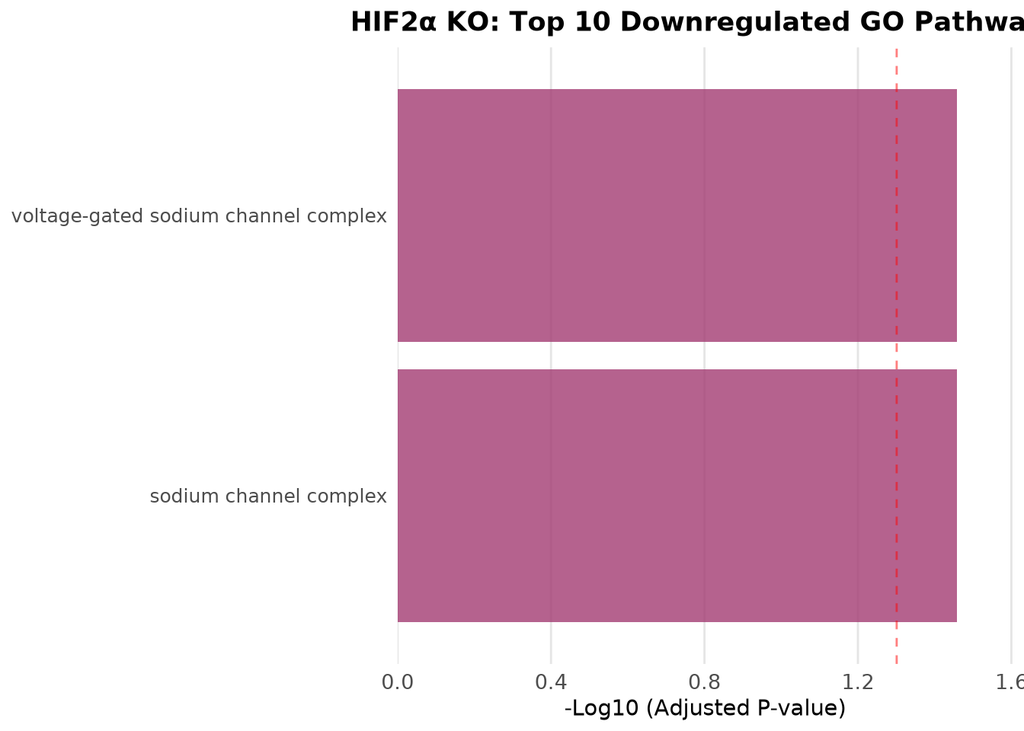

```r
ggsave("HIF1aKO_bar.svg", width = 10, height = 6, unit = "in")
ggsave("HIF1aKO_bar.png", width = 10, height = 6, unit = "in")

# HIF2a downregulated pathways (top 10)
p_hif2a_path <- create_pathway_barplot(
  as.data.frame(hif2a_go_down),
  "HIF2α KO: Top 10 Downregulated GO Pathways",
  n_pathways = 10,
  bar_color = "#A23B72"
)

print(p_hif2a_path)
```

```r
ggsave("HIF2aKO_bar.svg", width = 10, height = 6, unit = "in")
ggsave("HIF2aKO_bar.png", width = 10, height = 6, unit = "in")
```

[output not shown]

Warning: Your system is mis-configured: ‘/etc/localtime’ is not a symlinkR version 4.4.1 (2024-06-14) Platform: x86_64-pc-linux-gnu Running under: Red Hat Enterprise Linux 9.6 (Plow)

Matrix products: default BLAS/LAPACK: FlexiBLAS OPENBLAS; LAPACK version 3.10.1

locale: [1] LC_CTYPE=C.UTF-8 LC_NUMERIC=C LC_TIME=C.UTF-8 LC_COLLATE=C.UTF-8 LC_MONETARY=C.UTF-8 LC_MESSAGES=C.UTF-8 LC_PAPER=C.UTF-8  
[8] LC_NAME=C LC_ADDRESS=C LC_TELEPHONE=C LC_MEASUREMENT=C.UTF-8 LC_IDENTIFICATION=C

time zone: NA tzcode source: system (glibc)

attached base packages: [1] stats4 stats graphics grDevices utils datasets methods base

other attached packages: [1] clusterProfiler_4.12.0 org.Hs.eg.db_3.19.1 AnnotationDbi_1.66.0 ggrastr_1.0.2 ggrepel_0.9.5 ggnewscale_0.4.10  
[7] rtracklayer_1.64.0 lubridate_1.9.3 forcats_1.0.0 stringr_1.5.1 dplyr_1.2.1 purrr_1.0.2  
[13] readr_2.1.5 tidyr_1.3.2 tibble_3.2.1 ggplot2_4.0.3 tidyverse_2.0.0 DESeq2_1.44.0  
[19] SummarizedExperiment_1.34.0 Biobase_2.64.0 MatrixGenerics_1.16.0 matrixStats_1.3.0 GenomicRanges_1.56.1 GenomeInfoDb_1.40.1  
[25] IRanges_2.38.0 S4Vectors_0.42.0 BiocGenerics_0.50.0